# Eksploracja danych dotyczących zachorowań na nowotwory piersi w Polsce

Dominik Ambroziak, Michał Jaworski, Iwona Majewska, Krzysztof Smutek

17 maja 2016

# Wstęp

W poniższym raporcie analizowane są dane dotyczące zachorowań na nowotwory piersi w Polsce w latach 2010-2012. Dostępne dane zawierają informacje o liczbie chorych w zależności od stadium choroby, powiatu, płci i grupy wiekowej. Celem raportu jest zbadanie, jak każda z wymienionych cech wpływa na liczbę zachorowań.

Liczby zachorowań zostały znormalizowane przez rozmiar populacji. Statystyki dotyczące liczby ludności w powiatach i podziału na płeć i grupę wiekową zostały zaczerpnięte z bazy demografia prowadzonej przez Główny Urząd Statystyczny, dostępnej pod adresem http://demografia.stat.gov.pl/bazademografia/. Rozważane grupy wiekowe to:

- 0 - 44 lata
- 45 - 54 lata
- 55 - 64 lata
- 65+ lat.

Analizowane były łączne całkowite liczby chorych w danym obszarze, a nie tylko nowe zachorowania. Ze względu na brak różnic w rozkładach pomiędzy poszczególnymi latami zdecydowaliśmy się na analizę danych z roku 2010.

# Rozkłady liczby chorych dla całego terytorium Polski

W pierwszej fazie analizy zbadaliśmy całkowitą liczbę zachorowań w podziale na płeć badanych.

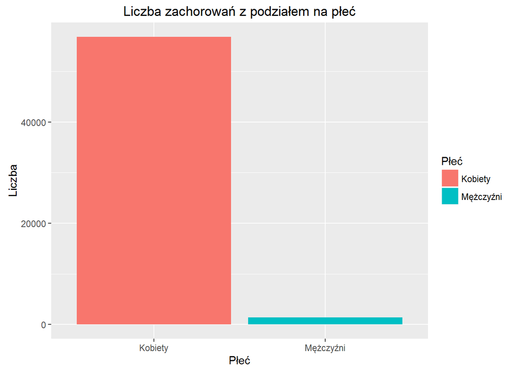

Okazuje się, że nowotwory piersi zdecydowanie częściej dotykają kobiety, niż mężczyzn. Meżczyźni stanowią zalednie 2,4% wszystkich chorych. Zdecydowaliśmy zbadać zależność procentu chorych w danym stadium nowotworu w stosunku do wszystkich chorych w zależności od płci.

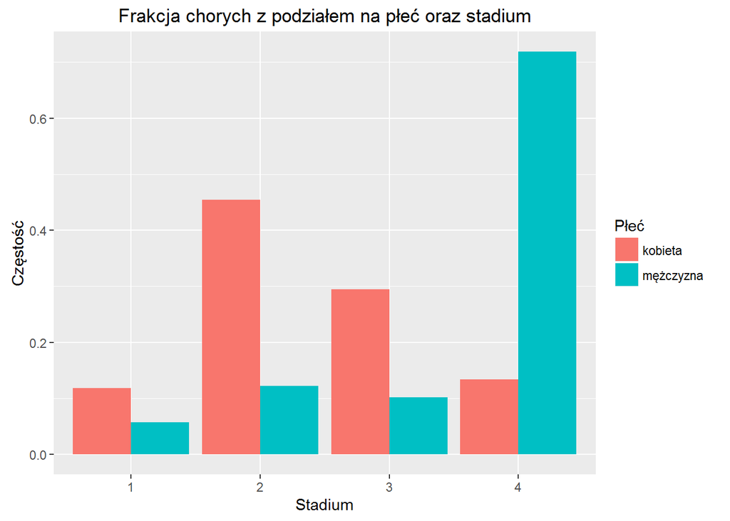

U największej liczby kobiet nowotwór występuje w stadium drugim. U mężczyzn zaś występuje zdecydowana przewaga stadium czwartego - u ponad 70% mężczyzn nowotwór osiąga stadium 4. Sugeruje to brak dobrej profilaktyki nowotworów piersi u mężczyzn.

Ze względu na specyficzny rozkład zachorowań i niewielką występowalność tej grupy chorób u mężczyzn, dalsze analizy zdecydowano się ograniczyć tylko do grupy kobiet.

Na kolejnym wykresie przedstawiono liczby chorych w zależności od wieku i stadium choroby.

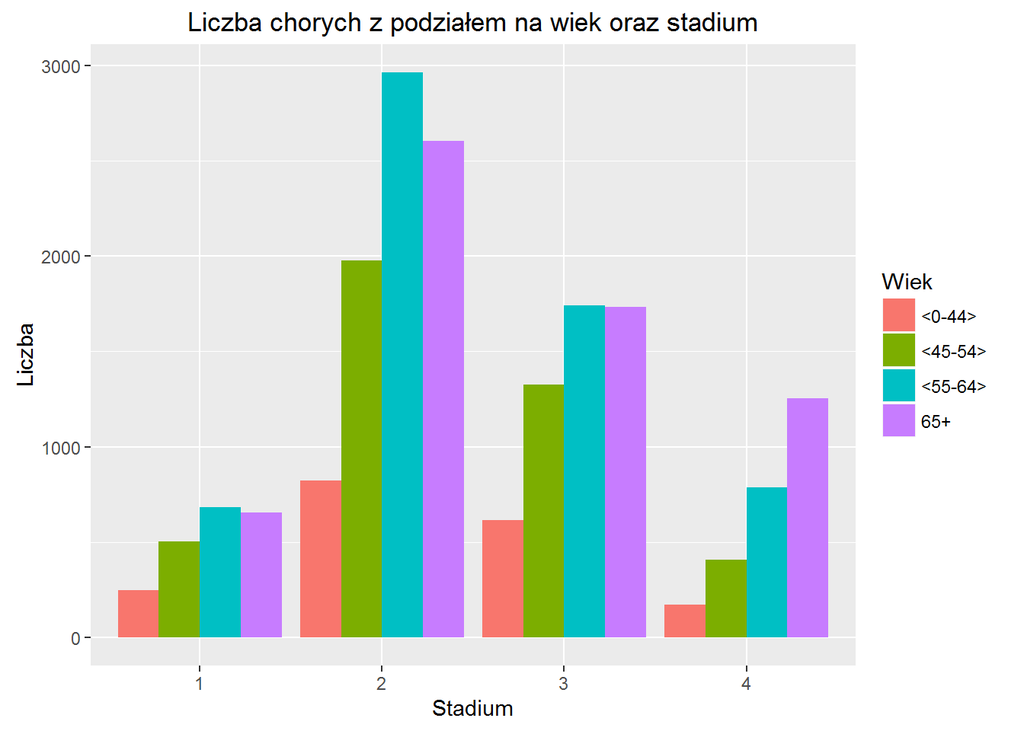

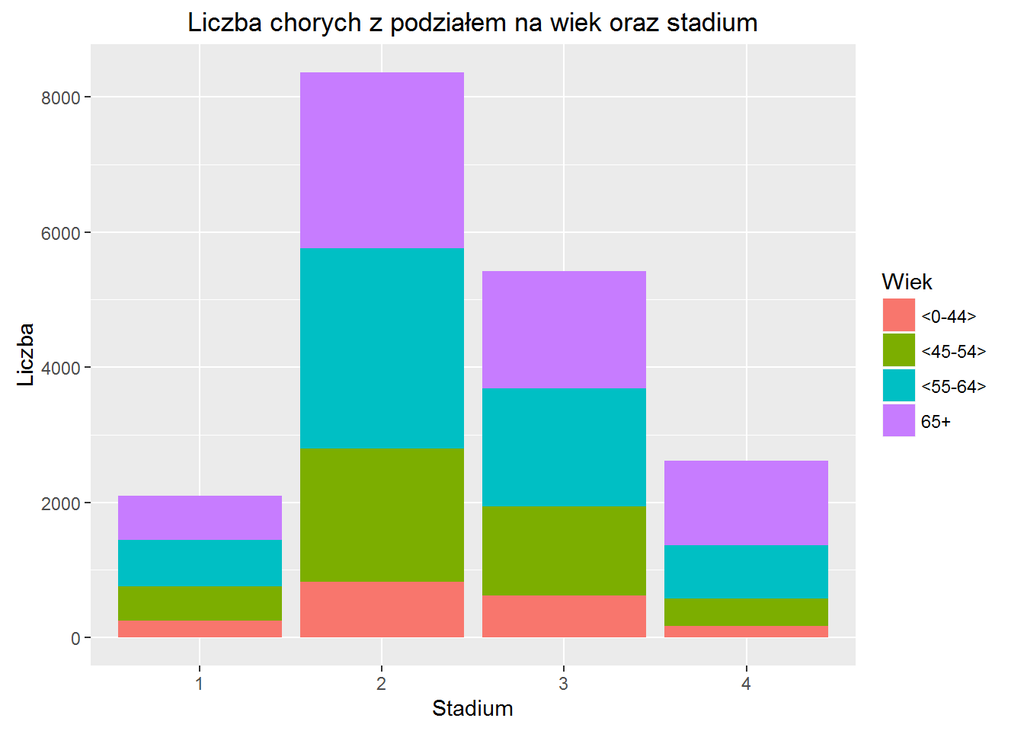

W każdym z czterech stadiów najmniej liczna jest grupa wiekowa 0 - 44 lata. Należy pamiętać, że grupa wiekowa 0 - 44 lat jest najliczniej reprezentowana w społeczeństwie - jest to ponad 50% populacji, więc częstość zachorowań na raka piersi w tej podgrupie jest zdecydowanie mniejsza niż w innych podgrupach. W stadiach 1 - 3 najliczniej reprezentowana jest grupa wiekowa 55 - 64 lata, zaś w stadium 4 jest to grupa 65+ lat. Sugeruje to, że później wykryty nowotwór jest w bardziej zaawansowanym stadium choroby.

# Rozkłady procentu zachorowań w zależności od regionu Polski

## Rozkłady zachorowań dla powiatów

Następny czynnik który sprawdziliśmy to zależność procentu zachorowań od regionu Polski. Przedstawiliśmy, w zależności od powiatu, liczbę zachorowań na 100 tys. mieszkańców.

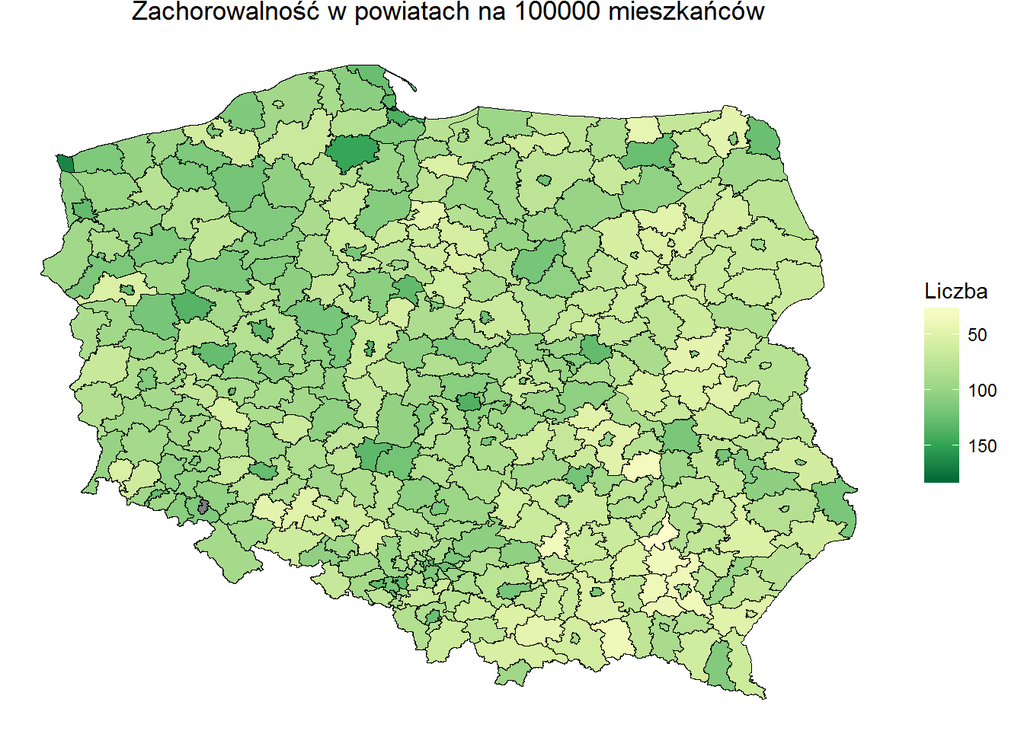

Powiatem o największej zachorowalności okazały się Sopot i Świnoujście, a o najmniejszej powiat tarnobrzeski i lipski. Na mapie wyraźnie widać, że miasta na prawach powiatu mają istotnie większą zachorowalność niż inne. Może być to spowodowane większą świadomością społeczną o konieczności badań profilaktycznych. Jednak bardziej uprawniony wydaje się wniosek, że miasta powiatowe mają bardziej wyspecjalizowane szpitale, czym przyciągają pacjentów z okolicznych powiatów.

Postanowiliśmy sprawdzić dokładniej zachorowalność w powiatach w zależności od tego, czy mamy do czynienia z miastem na prawach powiatu, czy z powiatem ziemskim. Przedstawiliśmy wykres średniego współczynnika zachorowań w zależności od rodzaju powiatu.

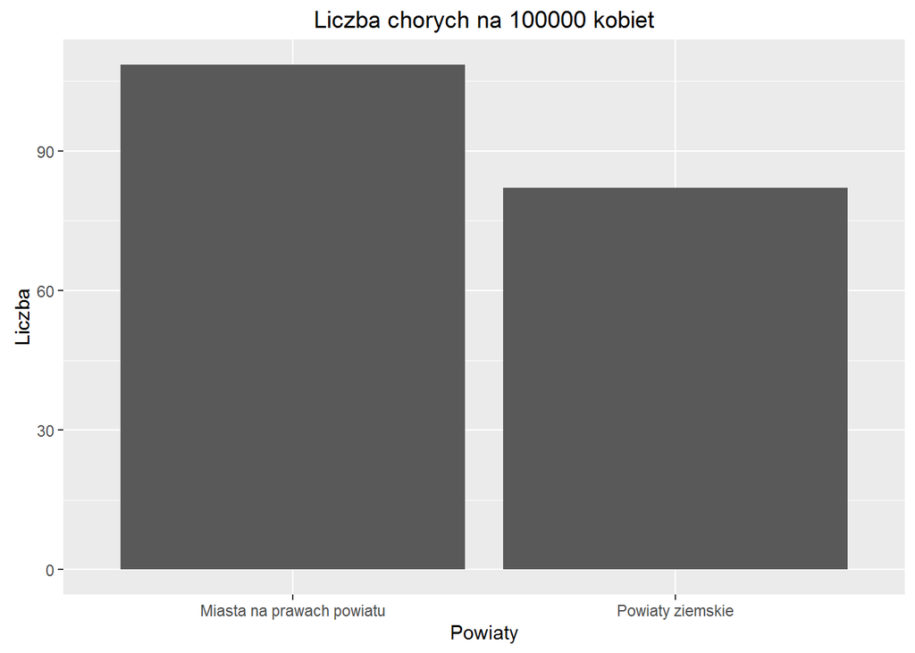

Tak jak przewidywaliśmy, powiaty grodzkie mają średnią zachorowalność o około 32% wyższą.

Aby sprawdzić hipotezę o jakości profilaktyki nowotworowej w zależności od rodzaju powiatu, przedstawiliśmy wykres średniego procentu zachorowań w zależności od podziału powiatu na ziemskie i grodzkie i podziału na stadia choroby.

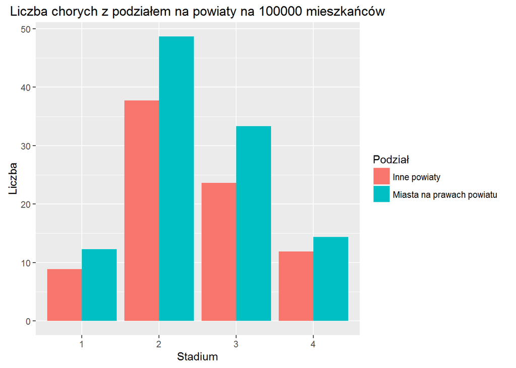

Podobnie jak na poprzednim wykresie, we wszystkich stadiach współczynniki są większe dla miast na prawach powiatu, niż dla innych powiatów. Największa różnica jest w stadium trzecim, najmniejsza w czwartym. O ile na poprzednim wykresie ta różnica wynosiła 32%, to dla samego stadium 3 współczynniki są wyższe o ponad 41%, natomiast dla stadium 4 wyższe tylko o 21%. Widać zróżnicowanie w zależności od rodzaju powiatu, jednak nie jest ono na tyle duże, byśmy mogli wyciągnąć konkretne wnioski.

## Rozkłady zachorowań dla województw

W przypadku podziału na powiaty przypuszczamy, że występuje mobilność chorych między powiatami, w zależności od specjalizacji i wyposażenia szpitali. Dlatego sprawdziliśmy, jak wyglądają statystyki procentu zachorowań dla województw, jako, że mobilność chorych między województwami zapewne jest mniejsza.

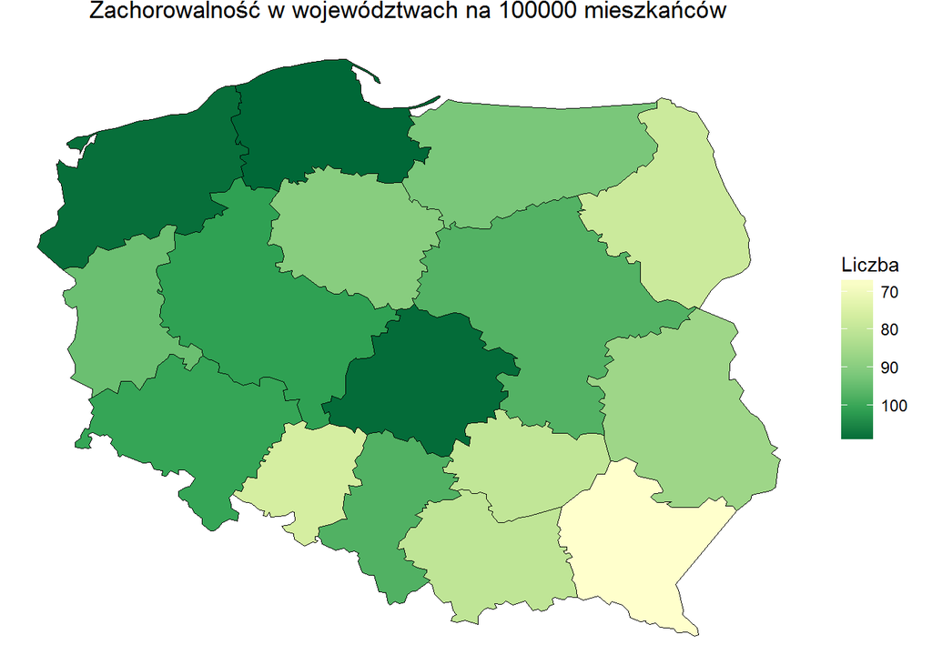

Największy procent zachorowań obserwujemy w województwie pomorskim, zaś najmniejszy w województwie podkarpackim. Sprawdziliśmy, jak wygląda statystyka zachorowań dla województw w zależności od stadium choroby.

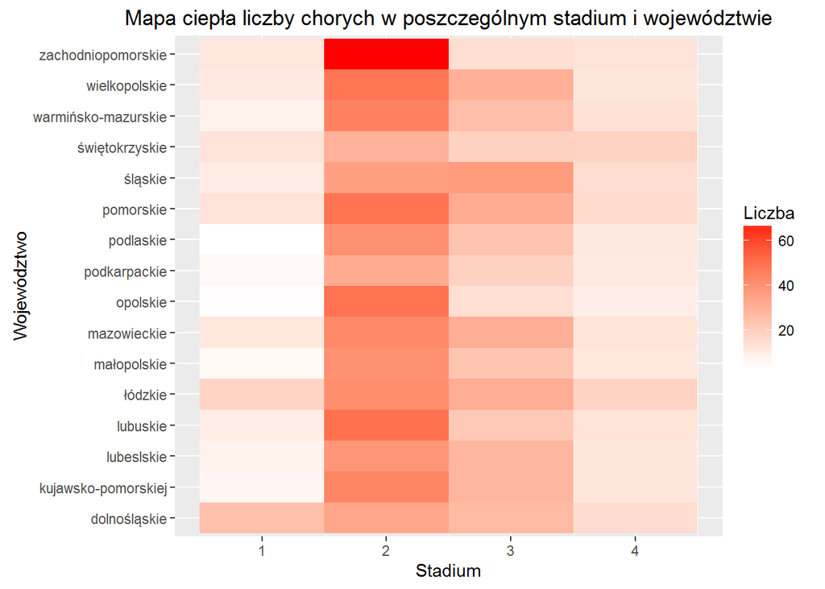

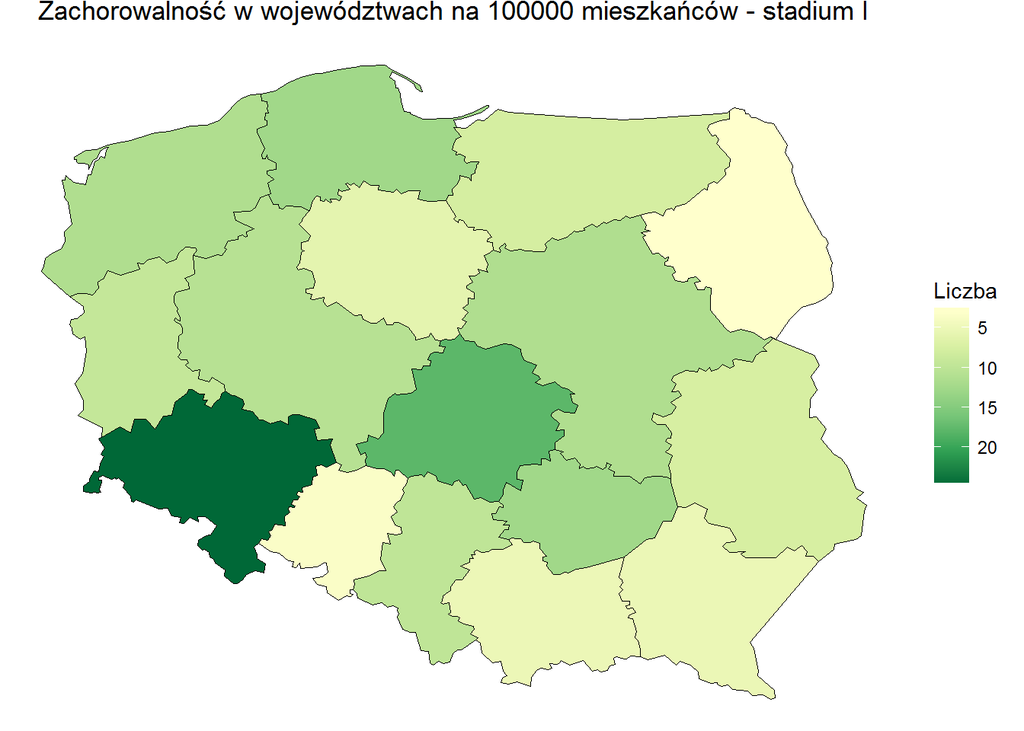

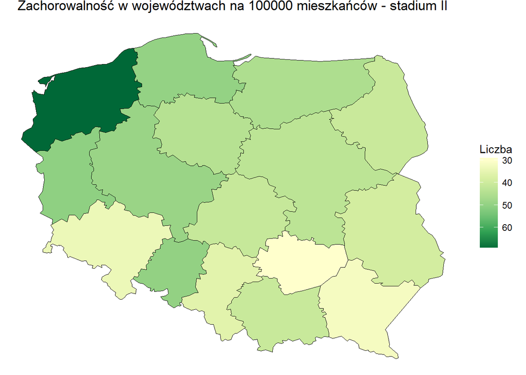

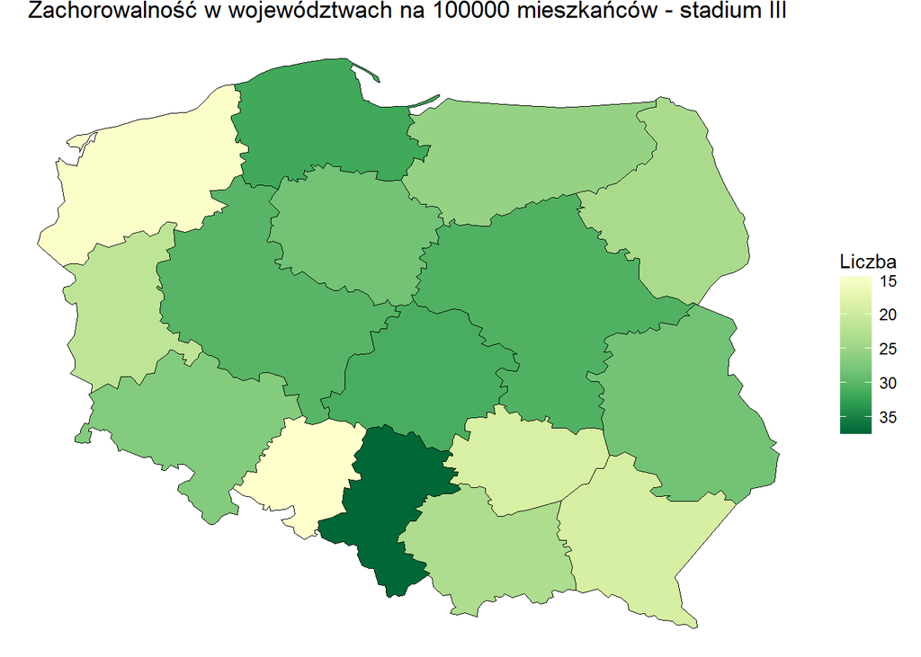

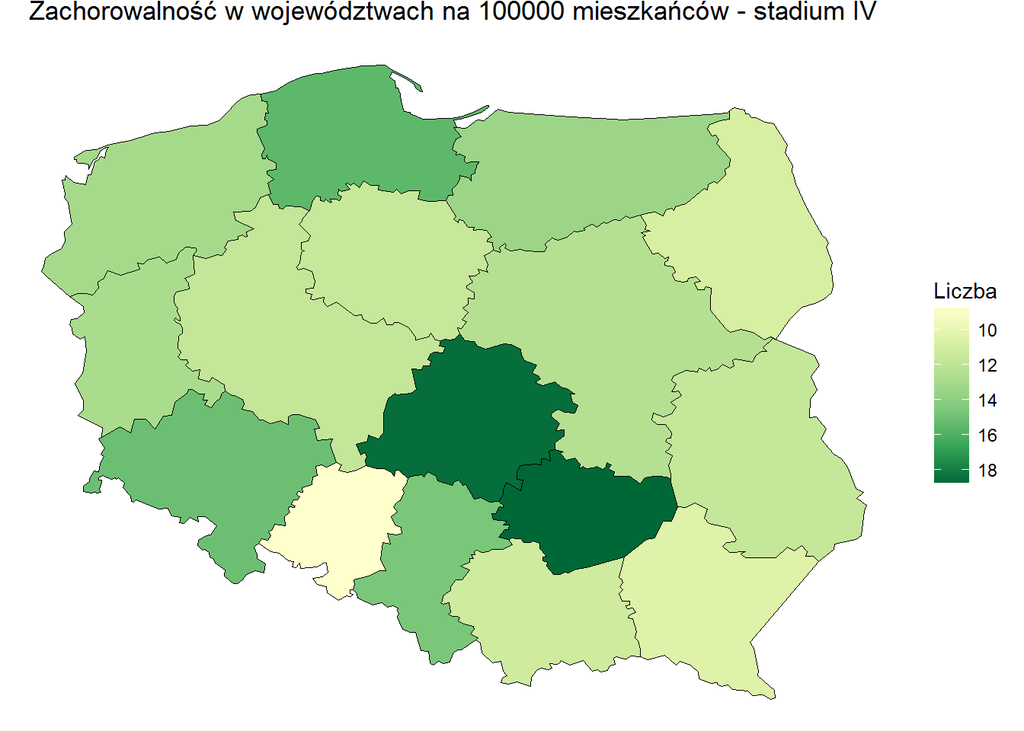

# Podsumowanie i wnioski

Nowotwory piersi zdecydowanie częściej występują u kobiet niż u mężczyzn. Dotykają też częściej kobiety powyżej 45 roku życia, przy czym bardziej zaawansowane stadia chorób częściej występują u osób starszych.